# KNN Blood

Dominika SkĂłrska & Zuzanna Zajkowska

21 maja 2019

## Zastosowanie metody k-najbliższych sąsiadów do klasyfikacji dawców krwi. (R)

Zastosowane metody klasyfikacji k-najbliższych sąsiadów do przewidzenia czy osoba odda krew w marcu czy nie, na podstawie pozostałych parametrów.

Dane:  
**Zmienne**:

- Recency - czas od ostatniego oddania krwi (w miesiącach)
- Frequency - częstość (ile razy ogólnie oddano krew)
- Monetary - ile w sumie oddano krwi w cm3
- Time - czas od pierwszego oddania krwi (w miesiącach)
- Whether he/she donated blood in March - zmienna prognozowana: czy dawca odda krew w Marcu

Celem projektu jest zbudowanie zbioru treningowego i testowego, zbudowania modelu w celu zbadania trafności algorytmu KNN dla prognozowania tego czy dawca odda krew w danym miesiącu na bazie wymienionych wyżej zmiennych.

## Metoda k-najbliższych sąsiadów

**Opis metody:**  
Założenia: Dany jest zbiór uczący. Każdy przypadek w tym zbiorze zawiera wektor niezależnych zmiennych i wartość zmiennej zależnej Y. Dany jest przypadek C zawierający wektor zmiennych niezależnych. Dla tego przypadku chcemy prognozować wartość zmiennej zależnej Y

**Algorytm:**

- Porównanie niezależnych zmiennych przypadku C z wartościami tych zmiennych dla każdego przypadku ze zbioru treningowego.
- Wybór k (wcześniej określona liczba) najbliższych do C przypadków ze zbioru treningowego.
- Definicja prognozy
- Średnia wartość zmiennych zależnych dla wybranych obserwacji w przypadku problemu regresyjnego
- Przydział najczęściej pojawiającej się klasy spośród wybranych obserwacji w przypadku problemu klasyfikacji

Algorytm K - najbliższych sąsiadów jest szczególnie użyteczny, kiedy zależność pomiędzy zmiennymi zależnymi a niezależnymi jest skomplikowana lub nietypowa (np. niemonotoniczna), tzn. trudna do modelowania w klasyczny sposób. W przypadku gdy ta zależność jest łatwa do interpretacji (np. liniowa), i zbiór nie zawiera wartości odstających, klasyczne metody (np. regresja liniowa) dają zazwyczaj lepsze rezultaty.

## Podział na zbiór uczący i testowy

Dane zostały podzielone w stosunku 7:3 na zbiór uczący i testowy. Algorytm dopasuje model do zbioru uczącego i na tej podstawie możliwe będzie wykonanie prognozy dla zbioru testowego i porównnie wyników z rzeczywistymi wartościami.

```r
set.seed(101)
split <- sample.split(dane_final$donated, SplitRatio = 0.70)
train <- subset(dane_final, split == TRUE)
test <- subset(dane_final, split == FALSE)
```

## Wybór liczby “k”

Innym spoosbem na wyznaczenie liczby “k” jest obliczenie pierwiastka z liczby wszystkich obserwacji.

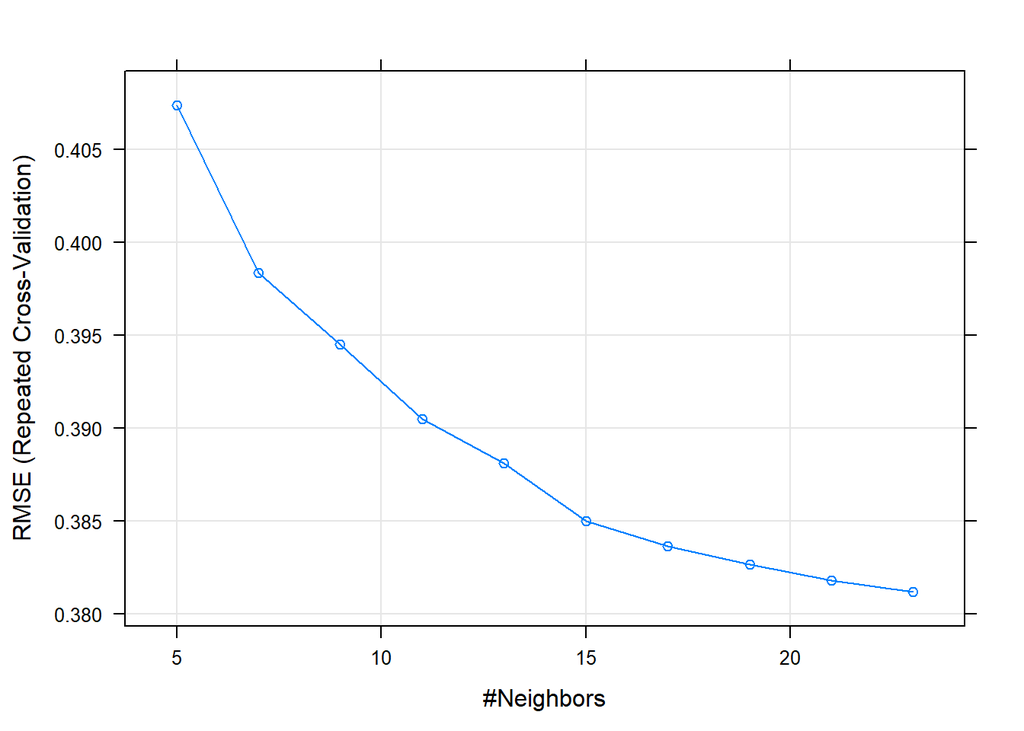

```r
set.seed(400)
ctrl <- trainControl(method = "repeatedcv", repeats = 3)
knnFit <- train(donated ~ ., data = train, method = "knn", trControl = ctrl, preProcess = c("center","scale"),tuneLength = 10)
plot(knnFit)
```

```r
sqrt(nrow(train))
```

```
## [1] 22.89105
```

## Budowa modelu, prognoza i określenie trafności

```r
set.seed(101)
predicted_21 <- knn(train[1:4], test[1:4], train$donated, k = 21)
set.seed(101)
predicted_22 <- knn(train[1:4], test[1:4], train$donated, k = 22)
```

### Przedstawienie wyników:

Na podstawie parametrów: recency, fequency, monetary, time zbudowany został model przewidujący czy dany dawca odda krew w najbliższym miesiącu. Wynik przyjmuje postać liczby binarnej, dla której “1” oznacza oddanie krwi, a “0” nie.

Wyniki zbadano dla 2 opcji: k=21 oraz k=22.

**k = 21**

Confusion matrix and rates:

```r
conf_matrix21 <- table(predicted_21, test$donated)
msl_rate_21 <- mean(test$donated != predicted_21)
accuracy_21 <- (conf_matrix21[1,1] + conf_matrix21[2,2])/nrow(test)
conf_matrix21
```

```
##
## predicted_21   0   1
##            0 167  48
##            1   4   5
```

```r
msl_rate_21
```

```
## [1] 0.2321429
```

```r
accuracy_21
```

```
## [1] 0.7678571
```

Błędnie sklasyfikowano 23,2% przypadków ze zbioru testowego.

Poprawnie sklasyfikowano 76,8% przypadków ze zbioru testowego.

**k = 22**

Confusion matrix and rates:

```r
conf_matrix22 <- table(predicted_22, test$donated)
msl_rate_22 <- mean(test$donated != predicted_22)
accuracy_22 <- (conf_matrix22[1,1] + conf_matrix22[2,2])/nrow(test)
conf_matrix22
```

```
##
## predicted_22   0   1
##            0 164  47
##            1   7   6
```

```r
msl_rate_22
```

```
## [1] 0.2410714
```

```r
accuracy_22
```

```
## [1] 0.7589286
```

Błędnie sklasyfikowano 24,1% przypadków ze zbioru testowego.

Poprawnie sklasyfikowano 75,9% przypadków ze zbioru testowego.

**Minimalnie lepsze wyniki daje zastosowanie algorytmu dla k = 21, dla którego jesteśmy w stanie oszacować wyniki z prawdopodobieństwem na poziomie 76,8%.**